# Bayes Checkpoint 4

#### Logistic regression model

I will build a logistic regression model to predict if a player will play again after having surgery ($\pi$). In creating this model, I will consider the following predictors:  
- $X_1$, which represents if a player is a starter or a reliever  
- $X_2$, a continuous variable representing the total number of innings pitched by a player prior to their surgery  
- $X_3$, the player’s average WHIP prior to their surgery  
- $X_4$, an indicator variable of if a player was a high school draftee

I will start this model with a weak prior on $\beta_{0c}$, which represents the probability of if a player will play again following their surgery. Based on data, about 73% of players played again following their surgery. I would estimate the true mean to fall somewhere between 0.6 and 0.85. Thus, I set the prior for $\beta_{0c} \sim N(1, 0.35^2)$. Thinking about this in meaningful terms, we estimate the odds of a player playing again after surgery to reasonably be between $(e^{1-2*0.35}, e^{1+2*0.35}) = (1.35, 5.47)$ and thus the probability to be between $(\frac{1.35}{1 + 1.35}, \frac{5.47}{5.47 + 1}\right) \approx (0.5744, 0.8455)$. I will utilize weakly informative priors for the other coefficients.

**Note: not sure why but prior summary does not seem to be giving me appropriate priors and only gave me 3 instead of 4**.

The model as a whole can be written as follows:
$$\begin{split}
Y_i | \beta_0, \beta_1, \beta_2, \beta_3 & \sim Bern(\pi_i) \;\; \text{ with } \;\; \log\left(\frac{\pi_i}{1-\pi_i}\right) = \beta_0 + \beta_1 X_{i1} + \beta_2 X_{i2} + \beta_3 X_{i3} + \beta_3 X_{i4} \\
\beta_{0c} & \sim N(1, 0.35^2) \\
\beta_1 & \sim N(0, 5.0209^2) \\
\beta_2 & \sim N(0, 0.0059^2) \\
\beta_3 & \sim N(0, 4.0813^2) \\
\beta_4 & \sim N(0, 1). \\
\end{split}$$

```r
stats$starter <- as.factor(stats$starter)
played_after_mod <- stan_glm(played_after ~ starter + totalIP + avgWHIP + hs_draftee,
                             data = stats, family = binomial,
                             prior_intercept = normal(1, 0.35),
                             prior = normal(0, 2.5, autoscale = TRUE),
                             chains = 4, iter = 5000*2, seed = 84735)
prior_summary(played_after_mod)
```

```
## Priors for model 'played_after_mod'
## ------
## Intercept (after predictors centered)
##  ~ normal(location = 1, scale = 0.35)
##
## Coefficients
##   Specified prior:
##     ~ normal(location = [0,0,0,...], scale = [2.5,2.5,2.5,...])
##   Adjusted prior:
##     ~ normal(location = [0,0,0,...], scale = [5.0209,0.0059,4.0813,...])
## ------
## See help('prior_summary.stanreg') for more details
```

Looking at the tidy output of this model, I notice that the starter and high school draftee variables appear to be significant, and well as the innings pitched variable. They might be interpreted as follows:

When controlling for draftee status, innings pitched, and WHIP, we are 80% confident that the odds of playing again after having surgery are between $(e^{0.309}, e^{1.06}) = (1.36, 2.89)$ higher for starters than relievers.  
When controlling for if a pitcher is a starter or reliever, innings pitched, and WHIP, we are 80% confident that the odds of playing again after having surgery are between $(e^{0.024}, e^{0.849}) = (1.024, 2.34)$ higher for high school draftees than college draftees.

When controlling for if a pitcher is a starter or reliever, draftee status, and WHIP, we are 80% confident that the odds of playing again after having surgery are between $(e^{0.0006057279*100}, e^{0.001930939*100}) = (1.06, 1.21)$ higher for every 100 innings pitched.

```r
tidy(played_after_mod, effects = "fixed", conf.int = TRUE, conf.level = 0.80)
```

```
## # A tibble: 5 × 5
##   term           estimate std.error  conf.low conf.high
##   <chr>             <dbl>     <dbl>     <dbl>     <dbl>
## 1 (Intercept)    -0.0381   0.456    -0.672      0.507
## 2 starter1        0.683    0.286     0.309      1.06
## 3 totalIP         0.00122  0.000515  0.000606   0.00193
## 4 avgWHIP         0.245    0.261    -0.0570     0.620
## 5 hs_drafteeTRUE  0.430    0.319     0.0242     0.849
```

Evaluating the accuracy of this model with a cutoff of 0.7, the model’s accuracy is 61.9% which balances the model’s sensitivity and specificity pretty well. Unfortunately, this is lower than the no information rate (the fact that 73% of players in our model ended up playing again after the surgery).

```r
set.seed(84735)
cv_accuracy <- classification_summary_cv(
  model = played_after_mod, data = stats, cutoff = 0.7, k = 10)
cv_accuracy$cv
```

```
##   sensitivity specificity overall_accuracy
## 1   0.6379397   0.6497403         0.619254
```

#### Also tried a random forest

```r
stats$played_after <- as.factor(stats$played_after)
# Model Specification
rf_spec <- rand_forest() %>%
  set_engine(engine = 'ranger') %>%
  set_args(mtry = NULL, # size of random subset of variables; default is floor(sqrt(ncol(x)))
           trees = 1000, # Number of trees
           min_n = 2,
           probability = FALSE, # FALSE: hard predictions
           importance = 'impurity') %>%
  set_mode('classification') # change this for regression tree

# Recipe
data_rec <- recipe(played_after ~ hs_draftee + surgery_age + starter + kRate + totalIP + avgWHIP, data = stats)

# Workflows
data_wf_mtry3 <- workflow() %>%
  add_model(rf_spec %>% set_args(mtry = 3)) %>%
  add_recipe(data_rec)

set.seed(124)
data_fit_mtry3 <- fit(data_wf_mtry3, data = stats)

rf_OOB_output <- function(fit_model, model_label, truth){
    tibble(
          .pred_class = fit_model %>% extract_fit_engine() %>% pluck('predictions'), #OOB predictions
          class = truth,
          model = model_label
      )
}

#check out the function output
data_rf_OOB_output <- rf_OOB_output(data_fit_mtry3,'mtry3', stats %>% pull(played_after))

data_rf_OOB_output %>%
    group_by(model) %>%
    accuracy(truth = class, estimate = .pred_class)
```

```
## # A tibble: 1 × 4
##   model .metric  .estimator .estimate
##   <chr> <chr>    <chr>          <dbl>
## 1 mtry3 accuracy binary         0.739
```

```r
rf_OOB_output(data_fit_mtry3,'mtry3', stats %>% pull(played_after)) %>%
    conf_mat(truth = class, estimate= .pred_class)
```

```
##           Truth
## Prediction   0   1
##          0  24  22
##          1  61 211
```

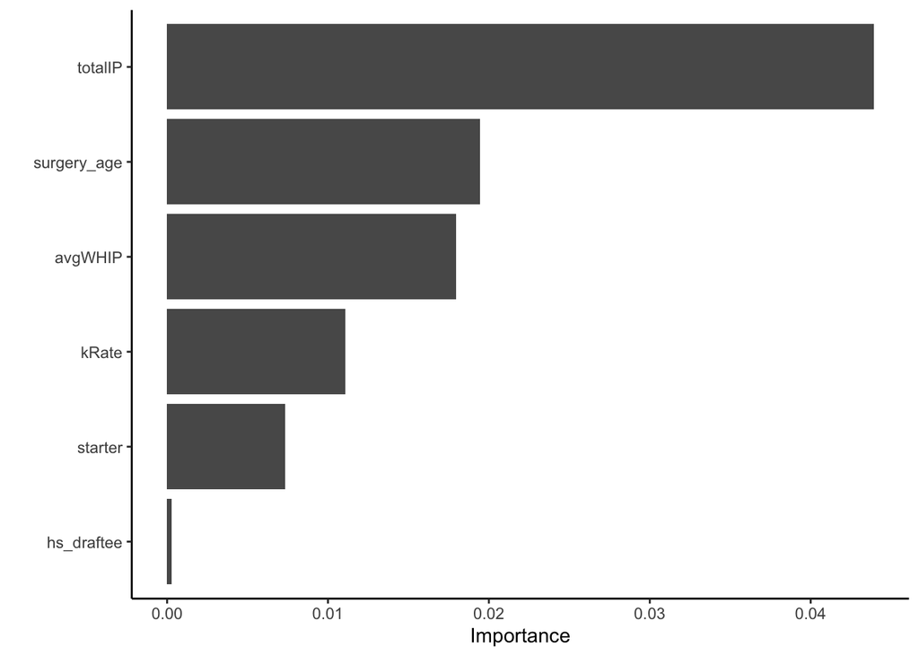

```r
data_wf_mtry3 %>%
  update_model(rf_spec %>% set_args(importance = "permutation")) %>% #based on permutation
  fit(data = stats) %>%
    extract_fit_engine() %>%
    vip(num_features = 30) + theme_classic()
```

The random forest was more accurate than the logistic regression model but not as easier to interpret. I am not sure I will want to use either of these models and will hold of on discussing the random forest for now.

### Model 2: Building on the WHIP model from checkpoint 3

**Goal: understand if there are significant predictors of WHIP**

```r
players <- seasonal_complete %>%
  group_by(Player) %>%
  count()
sample_rows <- sample(1:nrow(players), 800)
player_sample <- players[sample_rows, ]

seasonal_sample <- filter(seasonal_complete, Player %in% player_sample$Player)
```

First, is the variability in WHIP roughly normal? The assumption seems valid granted that we filter for seasons with over 5 IP.

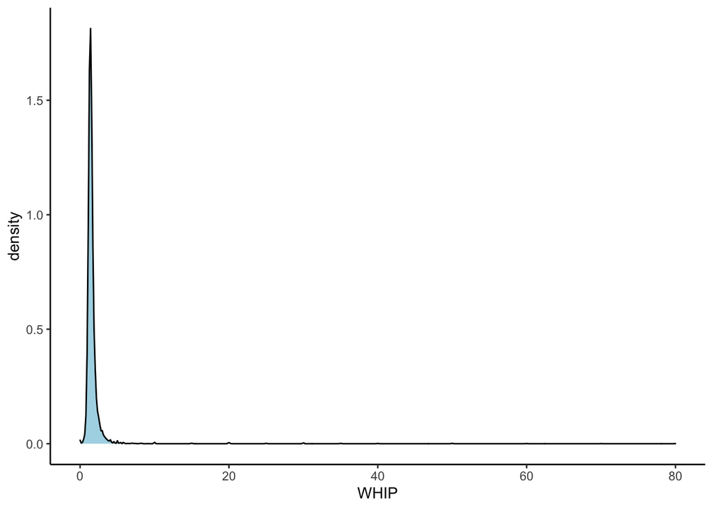

```r
#check it out using all the data - skewed
seasonal_complete %>%
  ggplot(aes(x=WHIP))+
  geom_density(fill = "lightblue")+
  theme_classic()
```

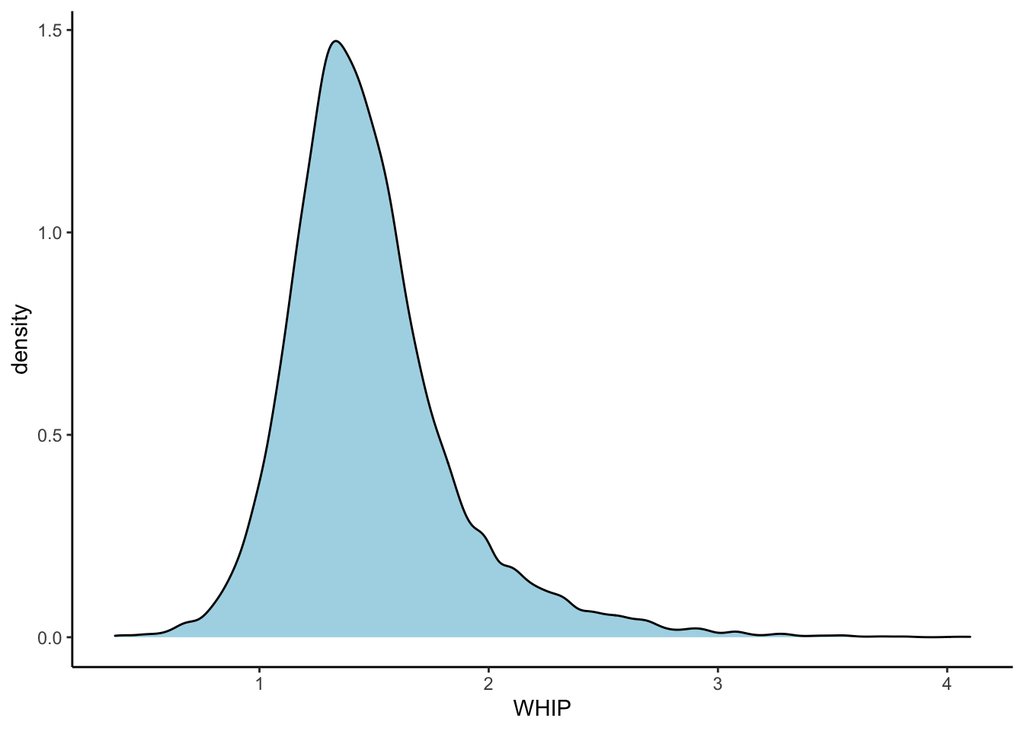

```r
#check it out once a player has pitched over 5 innings in a season. This eliminates the very high WHIPS that are due to players only pitching a couple of innings
seasonal_complete %>%
  filter(IP > 5) %>%
  ggplot(aes(x=WHIP))+
  geom_density(fill = "lightblue")+
  theme_classic()
```

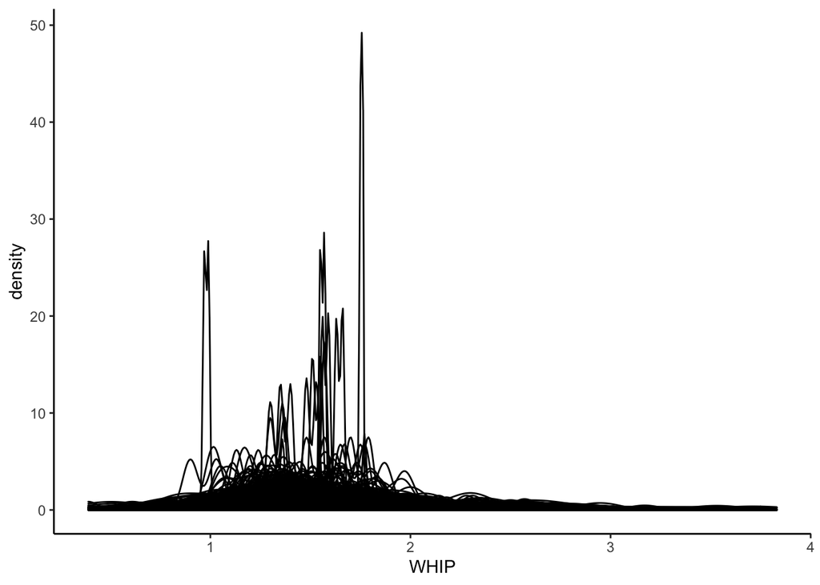

```r
#use sample to look at variability within individual players
seasonal_sample %>%
  arrange(Player) %>%
  filter(IP > 5) %>%
  #head(101) %>%
  ggplot(aes(x=WHIP, group = Player))+
  geom_density()+
  theme_classic()
```

Additionally, show the need for a hierarchical model. Without grouping the data by player, there does not appear to be a relationship between age and WHIP.

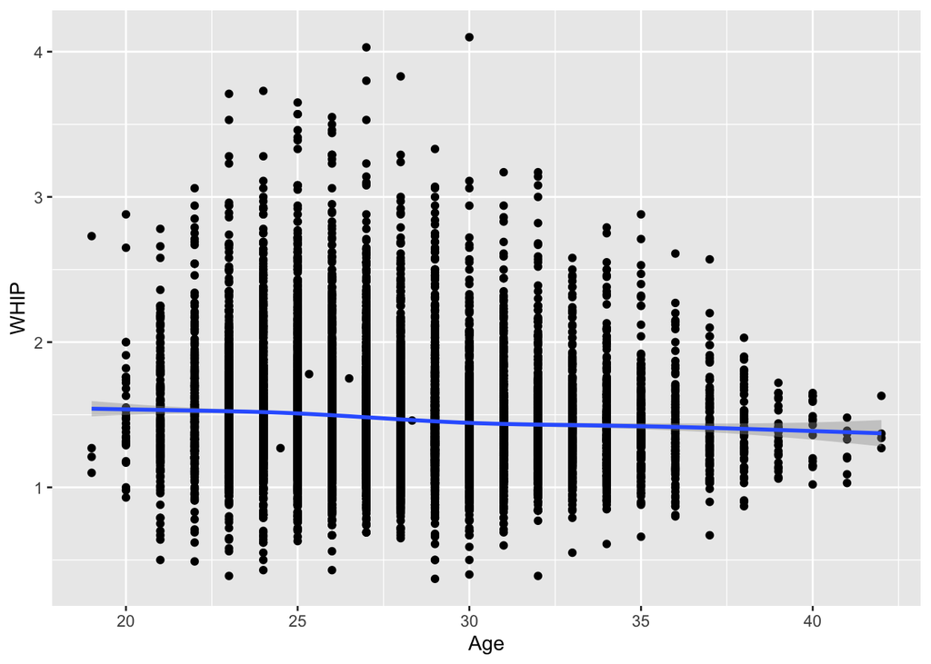

```r
seasonal_complete %>%
  filter(IP > 5) %>%
  ggplot(aes(x=Age, y= WHIP))+
  geom_point()+
  geom_smooth()
```

We can sample one hundred players and plot their trends in WHIP across their age.

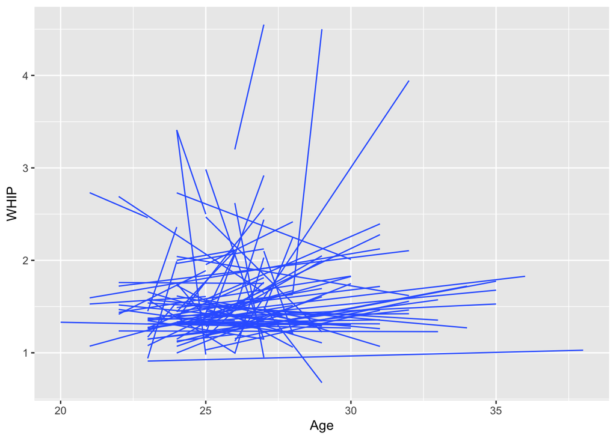

```r
seasonal_sample %>%
  mutate(player_id = as.numeric(factor(Player))) %>%
  filter(WHIP < 5, player_id < 100) %>%
  ggplot(aes(x=Age, y=WHIP, group = Player))+
  geom_smooth(method = "lm", se = FALSE, size = 0.5)
```

Now, build a model that groups the data. First, create indicators for if the player is a starter in each specific season (player started at least half the games he played in) and if the player has had a Tommy John surgery prior to this season.

```r
seasonal_sample_filtered <- seasonal_sample %>%
  filter(IP > 5, !is.na(WHIP)) %>%
  mutate(Player = fct_reorder(Player, WHIP, .fun = 'mean'),
         starter = case_when(GS/G < 0.5 ~ 0,
                                TRUE ~ 1),
         had_surgery = case_when(statsTime == "after" ~ 1,
                                 TRUE ~ 0))
```

Next, use a normal hierarchical model with varying intercepts to model seasonal WHIP by a player’s age, if they have yet had surgery in their career, if they were a starter in the particular season, and if they were a high school draftee (does not change by season). For the intercept we assume that WHIPs vary normally around the mean of about 1.4 and have a standard deviation of about 0.4. I use weakly informative priors for the other coefficients.